# Lista 2

Guilherme Schneider Markus (00330054) Lisiane Bueno Peitz (00172039)

2023-07-02

**Exercício 1)** Suponha agora $\phi$ desconhecido, mostre que $E(U_{\phi}) = 0$ para as distribuições Normal, Normal Inversa e Gama.

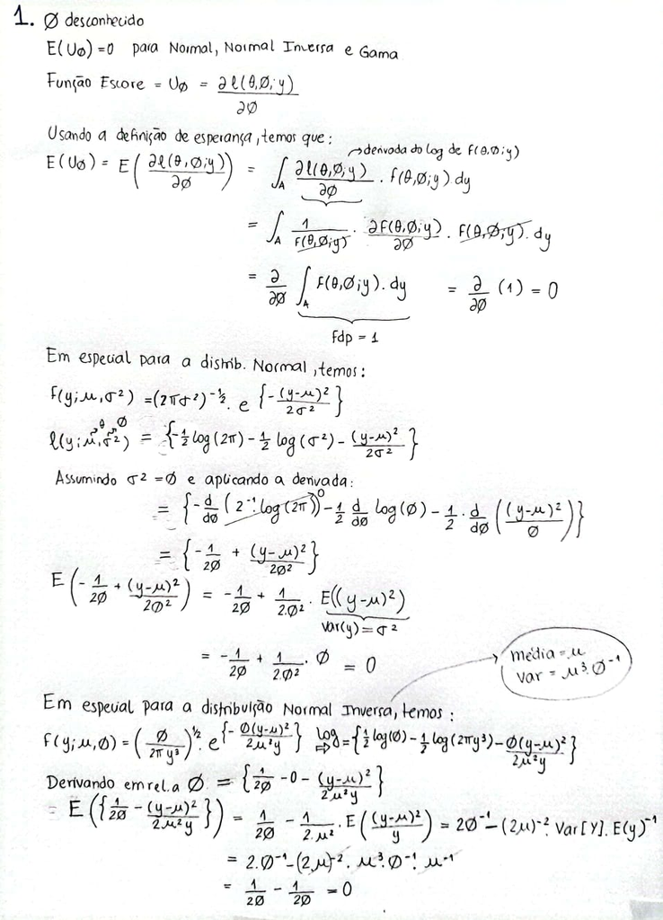

**Exercício 2)** Seja Y uma v.a. com distribuição gama, $Y \sim G(\mu,\nu)$ , com função densidade de probabilidade de expressa por

$$f(y;\mu,\nu) =
\frac{(\frac{\nu}{\mu})^{\nu}}{\Gamma(\nu)} y^{\nu-1}
exp(-\frac{y\nu}{\mu}), \hspace{0.5cm} y>0,$$
em que $\nu > 0,\hspace{0.1cm} \mu>0$. Derive a função desvio para um modelo gama.

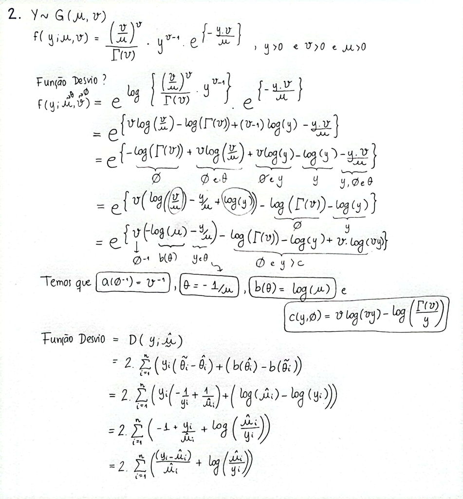

**Exercício 3)** Seja Y uma v.a. com distribuição binomial negativa, Y ∼ BN(µ, k), com função densidade de probabilidade de expressa por

$$f(y;\mu,k) =
\frac{\Gamma(k+y)}{\Gamma(k)y!} \frac{\mu^yk^k}{(\mu+k)^{k+y}},
\hspace{0.5cm} y = 0,1,2,...$$

em que $k$ é fixo, $k>0, \hspace{0.1cm} \mu>0$. Derive a função desvio para um modelo binomial negativo.

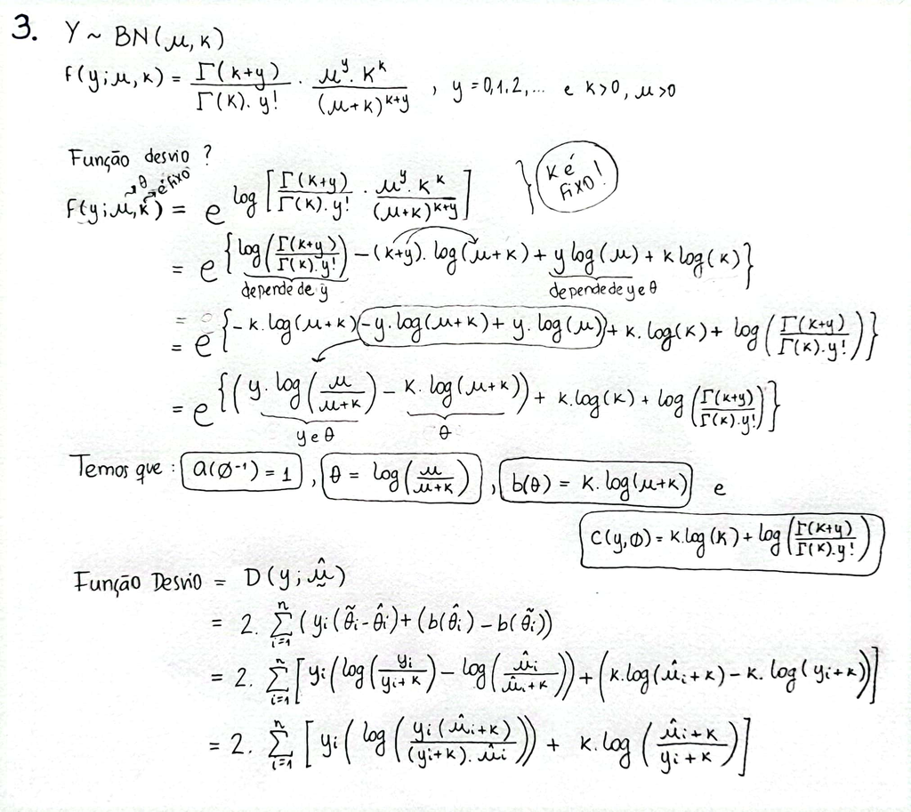

**Exercício 4)** Considere um modelo Poisson e seja o preditor linear dado por $\eta = X^T\beta$. Seja T uma v.a. com distribuição poisson, $Y\sim P(\mu)$, com função densidade de probabilidade de expressa por

$$f(y;\mu) = \frac{e^{-\mu}\mu^y}{y!},
\hspace{0.5cm} y = 0,1,2,...$$

em que $\mu>0$. Obtenha a estimativa de máxima verossimilhança para um determinado $\beta_j$ . Sugestão: utilizar o seguinte resultado (derivado em aula) das derivadas parcias.

$$\frac{\partial
l(\theta)}{\partial\beta_j} = \sum_{i=1}^n \phi \{
\sqrt{\frac{\omega_i}{V_i}} (y_i-\mu_{ij})x_{ij}\},$$

em que $\omega_i = \frac{(\frac{d\mu_i}{d\eta_i})^2}{V_i}$

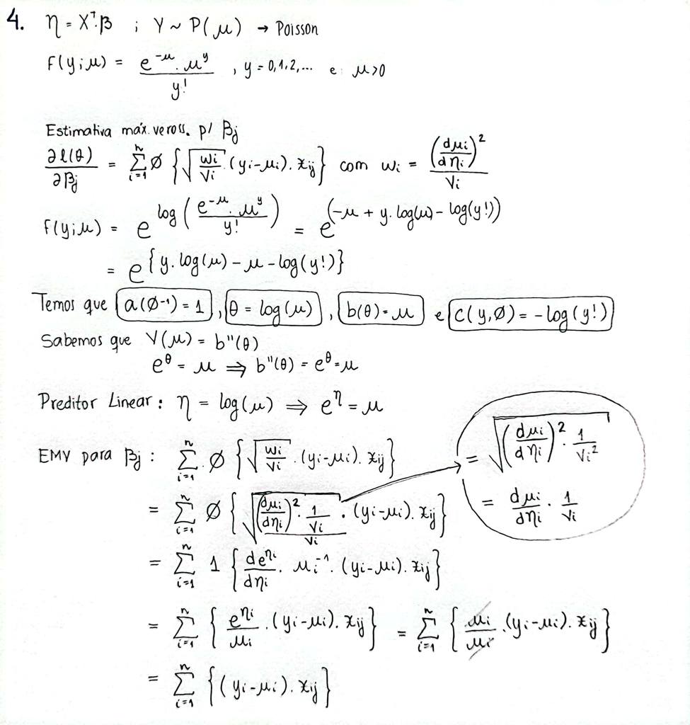

**Exercício 5)** Considere um modelo normal inverso, em que a variável resposta segue uma distribuição normal inversa denotada por $Y \sim IG(\mu,\sigma^2)$. Seja a função densidade de probabilidade para esta variável dada por

$$f(y;\mu,\sigma^2) =
(\frac{1}{2\pi\sigma^2y^3})^{1/2} exp [-
\frac{(y-\mu)^2}{2\mu^2\sigma^2y}], \hspace{0.5cm} y>0$$

em que $\mu>0, \hspace{0.1cm} \sigma^2>0.$ Encontre a estatística para o teste da razão de verossimilhança.

Obs.: Considere a seguinte equação: $\xi_{RV} = \phi \{D(y;\widehat\mu^{0}) - D(y;\widehat{\mu}) \}.$

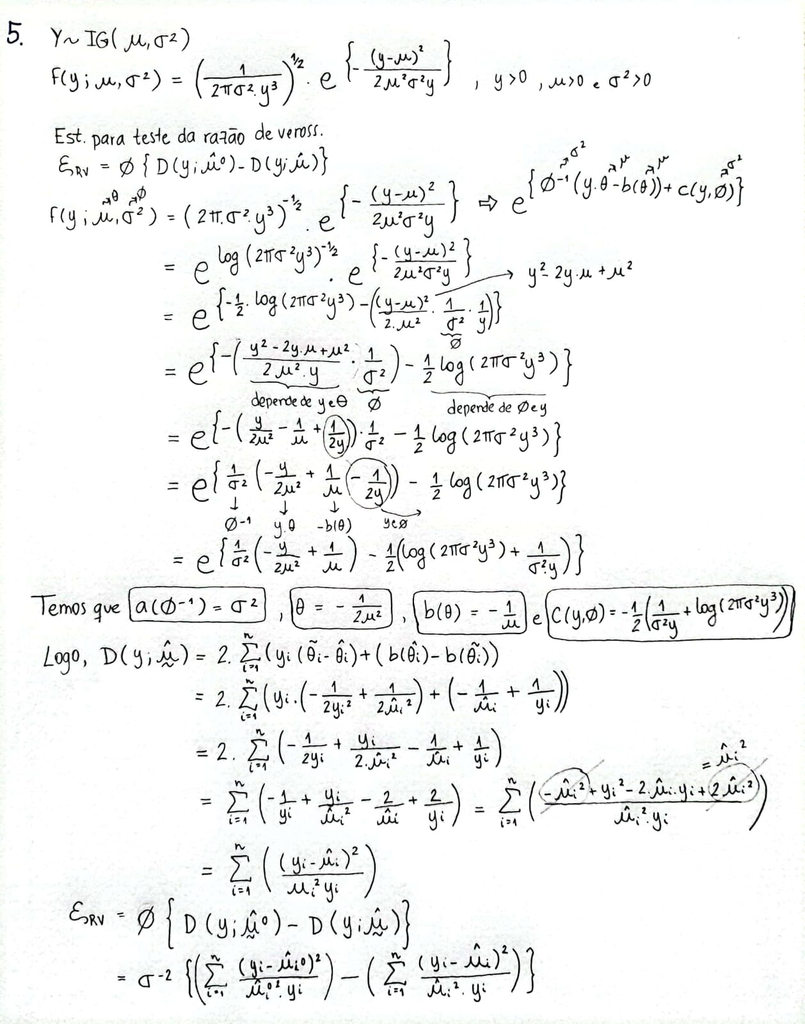

**Exercício 6)** Os dados apresentados no arquivo sinistros.csv, disponíveis no moodle, serão utilizados para ilustrar alguns conceitos de modelos lineares generalizados. A base é composta pelos dados de 500 clientes de determinado seguro de automóveis, sendo composta pelas seguintes variáveis:

• Idade- idade do segurado (em anos);

• Sexo – sexo do segurado;

• Usop – uso principal do veículo (cidade ou estrada);

• Anosest – anos de estudo do segurado;

• Claims – número de sinistros registrados pelo segurado num específico período de tempo (comum a todos os segurados da base).

O objetivo da análise é propor e ajustar um modelo de regressão para explicar o número de sinistros a partir das demais variáveis.

**Parte 1 - Análise descritiva**

Obtenha: a) Histograma com a curva de densidade estimada para os idades;

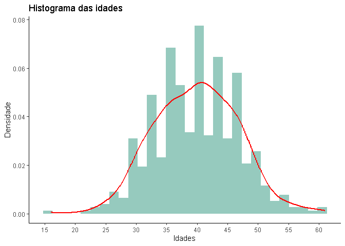

2. Medidas descritivas referentes aos sinistros e aos anos de estudo (média, mediana, desvio padrão, variância, coeficiente de variação) e distribuição de frequências às demais variáveis;

**Medidas descritivas dos Sinistros e dos Anos estudados**

|  | Sinistros | Anos estudados |
| --- | --- | --- |
| Média | 1.70 | 10.31 |
| Mediana | 1.00 | 10.00 |
| Desvio Padrão | 1.53 | 3.63 |
| Variância | 2.34 | 13.17 |
| CV | 90.08 | 35.20 |

**Distribuição de frequências para o Sexo**

|  | Quantidade | Porcentagem |
| --- | --- | --- |
| Fem | 191 | 38.2% |
| Masc | 309 | 61.8% |

**Distribuição de frequências para o Uso do Veículo**

|  | Quantidade | Porcentagem |
| --- | --- | --- |
| Cidade | 237 | 47.4% |
| Estrada | 263 | 52.6% |

3. Box-plots de Número de sinistros vs idade;

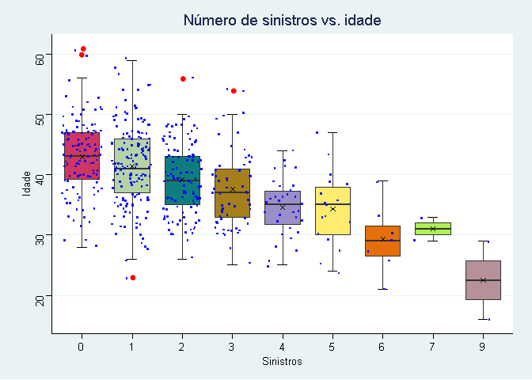

**Parte 2 - Ajuste de um modelo linear generalizado**

Ajuste um MLG com distribuição Poisson e função de ligação logarimtica (canônica).

```r
modelo_poisson1 <-glm(claims ~ idade*sexo*usop*anosest, family = poisson(link = log), data = sinistros)
modelo_poisson2 <- glm(claims ~ idade + sexo + usop + anosest, family = poisson(link = log), data = sinistros) # Modelo extremamente reduzido não pode ser utilizado pois a diferença deu significativa
modelo_poisson3 <- glm(claims ~ idade*usop + idade*sexo + anosest, family = poisson(link = log), data = sinistros)
# Modelo significativo porém a variável anosest não apresenta significancia.

modelo_poisson_final <- glm(claims ~ idade*usop + idade*sexo, family = poisson(link = log), data = sinistros) # Modelo final

anova(modelo_poisson3, modelo_poisson1, test = "Chisq")
```

```
## Analysis of Deviance Table
##
## Model 1: claims ~ idade * usop + idade * sexo + anosest
## Model 2: claims ~ idade * sexo * usop * anosest
##   Resid. Df Resid. Dev Df Deviance Pr(>Chi)
## 1       493     557.42
## 2       484     553.96  9   3.4671   0.9429
```

```r
AIC(modelo_poisson_final,modelo_poisson1)
```

```
##                      df      AIC
## modelo_poisson_final  6 1557.452
## modelo_poisson1      16 1572.949
```

A variável `anosest` não apresentou um acréscimo significativo no modelo. Já as interações duplas entre `idade*usop` e `ìdade*sexo` foram significarivas. Através dos testes da anova e AIC, observamos que não há diferença significativa entre o modelo maior e o reduzido. Ainda é importante observar que `sexoMasc` e `usopEstrada` são variáveis Dummy. Para 1 - Sexo Masculino e 0 - Sexo Feminino | 1 - Uso na estrada e 0 - Uso na cidade.

Apresente:

4. As estimativas dos coeficientes do modelo e os correspondentes erros padrões;

```
##
## Call:
## glm(formula = claims ~ idade * usop + idade * sexo, family = poisson(link = log),
##     data = sinistros)
##
## Coefficients:
##                   Estimate Std. Error z value Pr(>|z|)
## (Intercept)        1.22139    0.35797   3.412 0.000645 ***
## idade             -0.02037    0.00922  -2.210 0.027132 *
## usopEstrada        1.39501    0.44697   3.121 0.001802 **
## sexoMasc           1.00277    0.46012   2.179 0.029305 *
## idade:usopEstrada -0.03060    0.01160  -2.638 0.008343 **
## idade:sexoMasc    -0.02767    0.01195  -2.315 0.020604 *
## ---
## Signif. codes:  0 '***' 0.001 '**' 0.01 '*' 0.05 '.' 0.1 ' ' 1
##
## (Dispersion parameter for poisson family taken to be 1)
##
##     Null deviance: 733.84  on 499  degrees of freedom
## Residual deviance: 558.46  on 494  degrees of freedom
## AIC: 1557.5
##
## Number of Fisher Scoring iterations: 5
```

5. Intervalos de confiança (95%) para os parâmetros do modelo;

|  | 2.5 % | 97.5 % |
| --- | --- | --- |
| (Intercept) | 0.5200740 | 1.9232306 |
| idade | -0.0386212 | -0.0024828 |
| usopEstrada | 0.5202270 | 2.2714942 |
| sexoMasc | 0.1029394 | 1.9061593 |
| idade:usopEstrada | -0.0532924 | -0.0078399 |
| idade:sexoMasc | -0.0510695 | -0.0042351 |

6. As expressões do modelo ajustado nas escalas do preditor e da resposta;

Como temos uma poisson, a função ligação se da quando igualamos o preditor linear com parametro canônico.

$\mu_i = \beta_0 + \beta_1X_1 + \beta_2X_2 + \beta_3X_3 + \beta_4X_1X_2 + \beta_5X_1X_3$

$\eta_i = log(\mu_i) \rightarrow exp\{\eta_i\} = \mu_i$

Então temos que

`claims` = $exp \{ 1.22139 -0.02037 * idade + 1.39501 * usopEstrada + 1.00277 * sexoMasc - 0.03060 * (idade*usopEstrada) - 0.02767 * (idade*sexoMasc) \}$

7. A estimativa do parâmetro de dispersão por três métodos distintos;

**Estimativas de $\phi$**

**Método do Qui-Quadrado Residual**

```r
# GL
# Desvio residual / (número de observações - o posto da matriz modelo)
summary(modelo_poisson_final)$deviance/df.residual(modelo_poisson_final)
```

```
## [1] 1.130484
```

**Estimativa de máxima verossimilhança (EMV)**

```r
summary(modelo_poisson_final)$dispersion
```

```
## [1] 1
```

**Método dos Momentos estimados (MME)**

```r
residuos <- residuals(modelo_poisson_final, type ="pearson")
var(residuos)
```

[output not shown]

8. Descreva o modelo ajustado, especificando o preditor linear, a função de ligação, o componente aleatório e o componente sistemático;

*Modelo ajustado:*

`claims` = $exp \{ 1.22139 -0.02037 * idade + 1.39501 * usopEstrada + 1.00277 * sexoMasc - 0.03060 * (idade*usopEstrada) - 0.02767 * (idade*sexoMasc) \}$

*Preditor linear:*

$\eta_i = X^{´}_i\beta$

*Função de ligação:* Logarítmica:

$\eta = g^{}(\mu) \rightarrow \eta_i = log(\mu_i)$

$\mu_i = g^{-1}(\eta_i)\rightarrow exp\{\eta_i\} = \mu_i$

*Componente aleatório:* $Y =\mu_i = exp\{\eta_i\}$

Y (variável resposta) = Número de sinistros registrados pelo segurado num específico período de tempo.

O componente aleatório é modelado por uma distribuição de Poisson.

*Componente sistemático:* $\eta_i = X^{´}_i\beta = \beta_0 + \beta_1X_1 + \beta_2X_2 + \beta_3X_3 + \beta_4X_1X_2 + \beta_5X_1X_3$

**Parte 3 - Comparação de modelos**

1. Ajuste novos modelos, considerando a mesma distribuição e função de ligação, mas com os seguintes preditores lineares:

• Modelo 2 - Nº sinistros ∼ idade + sexo + Usop;

```r
modelo_poisson_2 <-glm(claims ~ idade + sexo + usop, family = poisson(link = log), data = sinistros)
```

• Modelo 3 - Nº sinistros ∼ idade + sexo + Anosest;

```r
modelo_poisson_3 <-glm(claims ~ idade + sexo + anosest, family = poisson(link = log), data = sinistros)
```

• Modelo 4 - Nº sinistros ∼ idade*sexo + Anosest;

```r
modelo_poisson_4 <-glm(claims ~ idade * sexo + anosest, family = poisson(link = log), data = sinistros)
```

Obtenha, para cada modelo:

• O valor da log-verossimilhança maximizada, da deviance, da estatística $\chi^2$. Disponha-os numa tabela, para efeito de comparação;

|  | Log-Veross.Max | Deviance | Est. Qui-Q. |
| --- | --- | --- | --- |
| Modelo 2 | -784.3731 | 581.7538 | 383.2651 |
| Modelo 3 | -790.0154 | 593.0384 | 368.7026 |
| Modelo 4 | -780.8325 | 574.6727 | 352.9194 |
| Modelo final ajustado | -772.7258 | 558.4592 | 339.0427 |

• Usando o teste da razão de verossimilhanças, compare os modelos:

· Modelo 1 vs Modelo 2;

```r
anova(modelo_poisson_final, modelo_poisson_2, test = "F")
```

```
## Analysis of Deviance Table
##
## Model 1: claims ~ idade * usop + idade * sexo
## Model 2: claims ~ idade + sexo + usop
##   Resid. Df Resid. Dev Df Deviance      F    Pr(>F)
## 1       494     558.46
## 2       496     581.75 -2  -23.295 11.647 8.743e-06 ***
## ---
## Signif. codes:  0 '***' 0.001 '**' 0.01 '*' 0.05 '.' 0.1 ' ' 1
```

Fazendo o teste da razão de verossimilhanças observamos que existe diferênça significativa entre os modelos, sendo assim, não podemos reduzir o modelo1 para o modelo2, porque perdemos informações para a nossa estimação. *Observação:* O modelo com maior parametrização sempre prevalece quando o teste Qui-Quadrado da significativo.

· Modelo 1 vs Modelo 3;

```r
anova(modelo_poisson_final, modelo_poisson_3, test = "F")
```

```
## Analysis of Deviance Table
##
## Model 1: claims ~ idade * usop + idade * sexo
## Model 2: claims ~ idade + sexo + anosest
##   Resid. Df Resid. Dev Df Deviance     F    Pr(>F)
## 1       494     558.46
## 2       496     593.04 -2  -34.579 17.29 3.099e-08 ***
## ---
## Signif. codes:  0 '***' 0.001 '**' 0.01 '*' 0.05 '.' 0.1 ' ' 1
```

Fazendo o teste da razão de verossimilhanças observamos que existe diferênça significativa entre os modelos, sendo assim, não podemos reduzir o modelo1 para o modelo3, porque perdemos informações para a nossa estimação.

· Modelo 3 vs Modelo 4.

```r
anova(modelo_poisson_3, modelo_poisson_4, test = "F")
```

```
## Analysis of Deviance Table
##
## Model 1: claims ~ idade + sexo + anosest
## Model 2: claims ~ idade * sexo + anosest
##   Resid. Df Resid. Dev Df Deviance      F    Pr(>F)
## 1       496     593.04
## 2       495     574.67  1   18.366 18.366 1.823e-05 ***
## ---
## Signif. codes:  0 '***' 0.001 '**' 0.01 '*' 0.05 '.' 0.1 ' ' 1
```

Fazendo o teste da razão de verossimilhanças observamos que existe diferênça significativa entre os modelos, sendo assim, não podemos reduzir o modelo4 para o modelo3, porque perdemos informações para a nossa estimação.

A cada item, identifique o que está sendo testado e interprete adequadamente os resultados.

**Nota** – Como o parâmetro de dispersão, neste caso, é desconhecido, você deverá usar a distribuição F como referência para os testes (ver ?anova.glm). Como estimativa do parâmetro de dispersão, neste momento, você pode usar aquela fornecida pela função glm.

10. Faça um breve relato baseado nos resultados do modelo ajustado.

Concluimos que o modelo final ajustado na parte 2 do exercício, é o melhor modelo entre os citados. Quando comparamos ele com o modelo completo, temos:

```r
anova(modelo_poisson1, modelo_poisson_final, test = "F")
```

```
## Analysis of Deviance Table
##
## Model 1: claims ~ idade * sexo * usop * anosest
## Model 2: claims ~ idade * usop + idade * sexo
##   Resid. Df Resid. Dev  Df Deviance      F Pr(>F)
## 1       484     553.96
## 2       494     558.46 -10  -4.5023 0.4502 0.9219
```

A diferênça entre o modelo quadruplo e o modelo final, não apresenta diferença significativa, ou seja, a redução de interação entre algumas variáveis e até mesmo eliminação de uma delas foi significamente aceitável.

**Exercício 7)** Para os dados da questão 6), compare os Intervalos Assintóticos e com o Intervalos via Bootstrap (ver arquivo passado em aula) para os coeficiente de regressão associados às covariáveis do modelo.

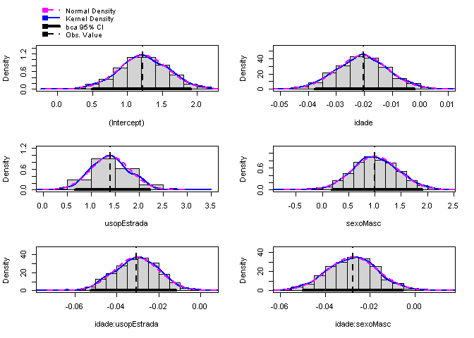

```r
set.seed(3317)
Bootstrap <- Boot(modelo_poisson_final, R = 999) # 999 reamostragens
hist(Bootstrap) # Histogramas para as estimativas dos parâmetros
```

```r
summary(Bootstrap) ### Por colunas: Numero de reamostragens;
```

```
##
## Number of bootstrap replications R = 999
##                    original    bootBias   bootSE   bootMed
## (Intercept)        1.221393  8.2860e-03 0.350483  1.224451
## idade             -0.020372 -3.1353e-04 0.009082 -0.020575
## usopEstrada        1.395005  2.0208e-03 0.411357  1.381277
## sexoMasc           1.002767  5.9205e-03 0.435138  0.997687
## idade:usopEstrada -0.030601 -3.2851e-05 0.010677 -0.030255
## idade:sexoMasc    -0.027666 -7.8074e-05 0.011309 -0.027637
```

Acima temos o resumo das estimativas obtidas por meio do bootstrap para o modelo ajustado ‘modelo_poisson_final’.

Seguem os seguintes valores estimados pelo bootstrap: para os parâmetros do modelo, para o vício (bootBias), para o erro padrão (bootSE) e para a mediana (bootMed).

compararando as duas últimas colunas com os resultados correspondentes no summary do modelo original (abaixo) podemos ver valores bastante similares.

```r
summary(modelo_poisson_final)
```

```
##
## Call:
## glm(formula = claims ~ idade * usop + idade * sexo, family = poisson(link = log),
##     data = sinistros)
##
## Coefficients:
##                   Estimate Std. Error z value Pr(>|z|)
## (Intercept)        1.22139    0.35797   3.412 0.000645 ***
## idade             -0.02037    0.00922  -2.210 0.027132 *
## usopEstrada        1.39501    0.44697   3.121 0.001802 **
## sexoMasc           1.00277    0.46012   2.179 0.029305 *
## idade:usopEstrada -0.03060    0.01160  -2.638 0.008343 **
## idade:sexoMasc    -0.02767    0.01195  -2.315 0.020604 *
## ---
## Signif. codes:  0 '***' 0.001 '**' 0.01 '*' 0.05 '.' 0.1 ' ' 1
##
## (Dispersion parameter for poisson family taken to be 1)
##
##     Null deviance: 733.84  on 499  degrees of freedom
## Residual deviance: 558.46  on 494  degrees of freedom
## AIC: 1557.5
##
## Number of Fisher Scoring iterations: 5
```

Abaixo estão respectivamente os intervalos de confiança de 95% usando bootstrap para os coeficientes estimados do modelo ‘modelo_poisson_final’ e os intervalos de confiança assintóticos de 95% para os coeficientes estimados do modelo.

Podemos ver que os intervalos são muito similares.

|  | 2.5 % | 97.5 % |
| --- | --- | --- |
| (Intercept) | 0.4926488 | 1.9014513 |
| idade | -0.0377500 | -0.0021150 |
| usopEstrada | 0.6607781 | 2.2206916 |
| sexoMasc | 0.1791148 | 1.9022111 |
| idade:usopEstrada | -0.0523770 | -0.0118201 |
| idade:sexoMasc | -0.0500462 | -0.0054812 |

|  | 2.5 % | 97.5 % |
| --- | --- | --- |
| (Intercept) | 0.5200740 | 1.9232306 |
| idade | -0.0386212 | -0.0024828 |
| usopEstrada | 0.5202270 | 2.2714942 |
| sexoMasc | 0.1029394 | 1.9061593 |
| idade:usopEstrada | -0.0532924 | -0.0078399 |
| idade:sexoMasc | -0.0510695 | -0.0042351 |